# Exploring the BRFSS data

## Setup

### Load packages

```r
library(ggplot2)
library(dplyr)
```

### Load data

```r
load("brfss2013.RData")
```

## Part 1: Data

I investigated below three questions in part 2 below through the Behavioral Risk Factor Surveillance System (BRFSS) dataset. BRFSS dataset is collected through monthly telephone interviews. This indicates that this is an observational study; interviewers collect data from a randomly selected adult who participates by using a landline telephone or cellular telephone (telephone-based survey). The data is simply collected as it is through sets of questions, but there is no manipulation by researchers. Therefore, the sample sizes dealt in the below three questions indicate that the studies are geneeralizable to the population in the US, because the data is collected from large populations over 30 years by random sampling. On the other hand, since observational studies do not control any confounding variable, cause-and-effect conclusions between variables cannot be made based on the data. Moreover, it is important to note that since the only way to collect the data is through telephone interviews, those who are not able to be reached via telephone at the time of the interview or who do not have either landline telephone or cellular telephone are not reflected in this data.

## Part 2: Research questions

**Research quesion 1:**

This question is designed to study a relationship between access to healthcare and duration of exercise (the survey question cardiovascular exercises, including running, calisthenics, golf, gardening, or walking). Therefore, it is important to note that weight training is not considered in this ‘duration of exercise.’ I wanted to find out whether those with healthcare access do longer exercise due to emotional security they feel, and those who do not have one exercise for a short amount of time.

I first took into consideration of those who have joint problems. As those who have such problems have difficulty in exercising, the variable ‘lmtjoin3’ is selected as a third variable to subset by. 3 variables are involved to study this question: hlthpln1 (whether one has healthcare or not), lmtjoin3 (whether one has joint problem or not), and exerhmm1 (duration of cardiovascular exercise such as, running, calisthenics, golf, gardening, or walking).

**Research quesion 2:**

This question is designed to study a relationship between the existence of children in household (explanatory variable as ‘children’) and the frequency of seatbelt use (seatbelt) with a possible confounding variable ‘X_educag’ which notes one’s education level.

I wanted to explore whether having children in household affects people to wear seatbelts more frequently. As one’s education can affect people to wear seatbelts more frequently, I only included those who at least graduated from high school.

**Research quesion 3:**

This question is designed to study a relationship between fruit intake and mental health. I selected two variables ‘frutda1_’, which represents fruit intake in times per day, and ‘qlmentl2’, which notes how many days one felt sad, blue, or depressed during the past 30 days.

As it is widely known that fruit consumption helps to fight depression, this question seeks to explore an association between fruit consumption in a day and frequency of feeling depressed. * * *

## Part 3: Exploratory data analysis

**Research quesion 1:**

First, since the population we are interested in are those who do not have any joint problem, we want to exclude those who have joint problems from our analysis. Through the filter command, I chose the particular population. At the same time, excluded those who answered NA on the questions of ‘whether one has joint problems or not’ and ‘whether one has healthcare plan or not.’

```r
brfss2013 %>%
filter(lmtjoin3 == "No", !is.na(hlthpln1)) %>%
group_by(hlthpln1) %>%
summarise(count=n())
```

```
## # A tibble: 2 x 2
##   hlthpln1 count
##   <fct>    <int>
## 1 Yes      72391
## 2 No        4539
```

Above table shows our target population. Within the population, there are 72,391 observations who have access to healthcare and 4,539 observations who do not.

Then, I created a new variable using above information. Our interested population is those who do not have joint problems. Therefore, I created a variable ‘PopQ1’ (population for question 1) in order to exclude those who have joint problems but have or not have access to healthcare.

```r
brfss2013 <- brfss2013 %>%
mutate(PopQ1 = ifelse(lmtjoin3 == "No" & hlthpln1 == "Yes", "Yes", ifelse(lmtjoin3 == "No" & hlthpln1 == "No", "No", NA)))
```

Noting the above information, I created boxplot with x-variable being PopQ1 and y-variable being exerhmm1. At the same time, in order to remove NAs from exerhmm1, I filtered them out from the boxplot.

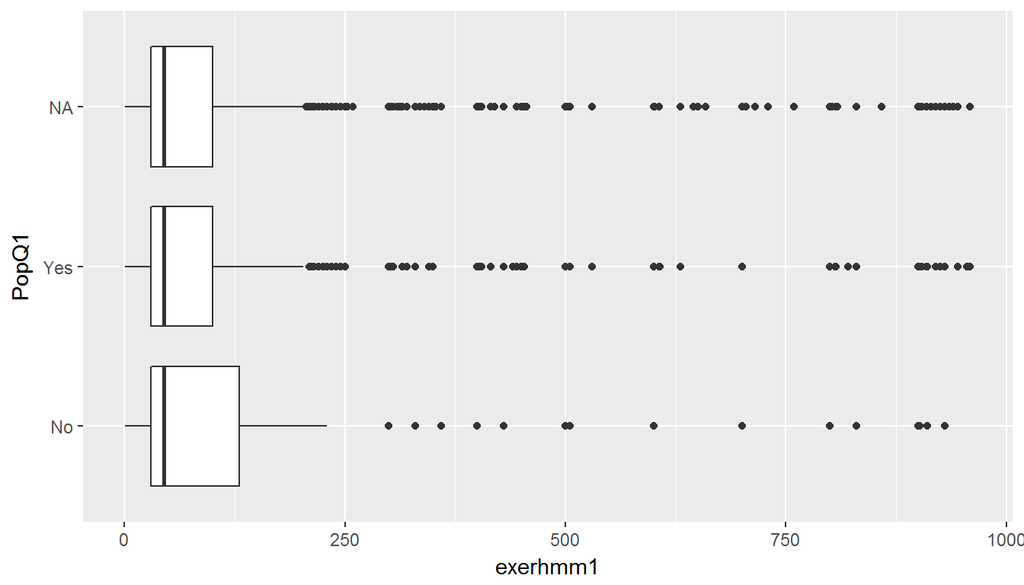

```r
brfss2013 %>%
filter(!(is.na(exerhmm1))) %>%
ggplot(aes(x = PopQ1, y = exerhmm1)) + geom_boxplot() + coord_flip()
```

From the boxplot above, we can see that the group without healthcare access (PopQ1 = “No”) has a slightly bigger interquartile range, but both those with healthcare access (PopQ1 = “Yes”) and those without have the same median. Moreover, outliers all plotted on the right side of the boxplot show that the distributions of the two groups are right-skewed. Since the data is right skewed, affected by extremely high observations, the comparison of robust statistics is necessary to explain the research question.

To specify 5 number summary (minimum, lower quartile, median, upper quartile, maximum), I utilized summary() function.

```r
with(brfss2013, by (exerhmm1, PopQ1, summary, na.rm = TRUE))
```

```
## PopQ1: No
##    Min. 1st Qu.  Median    Mean 3rd Qu.    Max.    NA's
##     1.0    30.0    45.0   112.1   130.0   930.0    1682
## --------------------------------------------------------
## PopQ1: Yes
##    Min. 1st Qu.  Median    Mean 3rd Qu.    Max.    NA's
##    1.00   30.00   45.00   92.41  100.00  959.00   21805
```

However, there are several factors that suggest that we need more research to explore this question: (1) the number of observations without healthcare access and (2) other health-related issues that hinders one from exercising.

First of all, there were more than 6 times number of observations in the group with healthcare. The size of the group should be similar to each other in order to study the relationship. Furthermore, a possible confounding factor is having health issues other than joint problems. There are many different types of health conditions that can hinder one from exercising for longer duration. This was not taken into account when studying above question.

As this study is observational, the result cannot infer any causal relationship between the two variables. Moreover, since the number of observations in the group without healthcare is significantly smaller than those with healthcare, for this specific question, the result cannot be generalizable to the whole population of those without healthcare.

**Research quesion 2:** The population this question deals with includes those with education in order to control the effects of education on the usage of seatbelts.

As our population should be those who at least graduated from high school, I made a new variable out of ‘X_educag’, which shows one’s education level, to only take into account those who received secondary education.

First, I checked ‘X_educag’ variable to grasp the whole population and different categories of this variable.

```r
brfss2013 %>%
group_by(X_educag) %>%
summarise(count=n())
```

```
## # A tibble: 5 x 2
##   X_educag                                    count
##   <fct>                                       <int>
## 1 Did not graduate high school                42213
## 2 Graduated high school                      142968
## 3 Attended college or technical school       134196
## 4 Graduated from college or technical school 170118
## 5 <NA>                                         2280
```

Then, I made ‘EdYN’ variable which indicates whether one completed secondary education “Yes” or not “No”. Therefore, all “Did not graduate high school” category was reassigned as “No” and the others were reassigned as “Yes”.

```r
brfss2013 <- brfss2013 %>%
mutate(EdYN = ifelse(X_educag == "Did not graduate high school", "No", "Yes"))
```

Then, I checked this new variable with summarise function.

```r
brfss2013 %>%
group_by(EdYN) %>%
summarise(count=n())
```

```
## # A tibble: 3 x 2
##   EdYN   count
##   <chr>  <int>
## 1 No     42213
## 2 Yes   447282
## 3 <NA>    2280
```

Also, I made a new variable out of ‘children.’ This variable shows how many children each household has. I made a categorical variable which notes whether a household has any children (“Yes”) or not (“No”).

First, I checked the ‘children’ variable with summarise function.

```r
brfss2013 %>%
group_by(children) %>%
summarise(count=n())
```

```
## # A tibble: 21 x 2
##    children  count
##       <int>  <int>
##  1        0 359478
##  2        1  53208
##  3        2  46682
##  4        3  19828
##  5        4   6924
##  6        5   2099
##  7        6    827
##  8        7    240
##  9        8    103
## 10        9     45
## # ... with 11 more rows
```

Then I made a variable ‘ChildrenYN’ simply to note whether a household has any children or not.

```r
brfss2013 <- brfss2013 %>%
mutate(ChildrenYN = ifelse(children == 0, "No", ifelse(children >= 1, "Yes", NA)))
```

Then, I checked this new variable with summarise function.

```r
brfss2013 %>%
group_by(ChildrenYN) %>%
summarise(count=n())
```

```
## # A tibble: 3 x 2
##   ChildrenYN  count
##   <chr>       <int>
## 1 No         359478
## 2 Yes        130023
## 3 <NA>         2274
```

Now with above two new variables, I can make another variable ‘EdandChildren’ which allows me to have 2 groups of people who completed high schoool education: those with children in their household and those without. This will be our explanatory variable.

```r
brfss2013 <- brfss2013 %>%
mutate(EdandChildren = ifelse(ChildrenYN == "Yes" & EdYN == "Yes", "Yes", ifelse(ChildrenYN == "No" & EdYN == "Yes", "No", NA)))
```

I checked the above created variable by doing the comparison of the three variables ‘EdYN’, ‘ChildrenYN’ and ‘EdandChildren’.

```r
brfss2013 %>%
group_by(EdYN, ChildrenYN, EdandChildren) %>%
summarise(count=n())
```

```
## # A tibble: 9 x 4
## # Groups: EdYN, ChildrenYN [?]
##   EdYN  ChildrenYN EdandChildren  count
##   <chr> <chr>      <chr>          <int>
## 1 No    No         <NA>           30495
## 2 No    Yes        <NA>           11635
## 3 No    <NA>       <NA>              83
## 4 Yes   No         No            327875
## 5 Yes   Yes        Yes           118107
## 6 Yes   <NA>       <NA>            1300
## 7 <NA>  No         <NA>            1108
## 8 <NA>  Yes        <NA>             281
## 9 <NA>  <NA>       <NA>             891
```

Above table shows that the variable ‘EdandChildren’ indicates two different groups that we are interested in: whether those who completed education have children or not in their households. Now, our explanatory variable is ready.

For our response variable, in order to simplify the analysis, I made a new variable ‘seatbeltcatg’ out of the ‘seatbelt’ variable (which indicates how frequent one wears seatbelts) in order to only consider 3 levels in how often people wear seatbelts.

```r
brfss2013 %>%
group_by(seatbelt) %>%
summarise(count=n())
```

```
## # A tibble: 7 x 2
##   seatbelt                      count
##   <fct>                         <int>
## 1 Always                       390327
## 2 Nearly always                 34494
## 3 Sometimes                     13718
## 4 Seldom                         5708
## 5 Never                          7445
## 6 Never drive or ride in a car   1148
## 7 <NA>                          38935
```

I grouped “Always” and “Nearly always” categories with “Yes”, “Sometimes” category is left as it is (but it acronym ‘St’), and “Seldom” and “Never” is combined with “No”. Those who have never droven or ridden a car is left out from the population we are interested in.

```r
brfss2013 <- brfss2013 %>%
mutate(seatbeltcatg = ifelse(seatbelt == "Always", "Yes", ifelse(seatbelt == "Nearly always", "Yes", ifelse(seatbelt == "Sometimes", "St", ifelse(seatbelt == "Never", "No", ifelse(seatbelt == "Seldom", "No", NA))))))
```

And checked whether this variable is created without any error. There are three levels as I conditioned: “Yes”, “Sometimes” “No”.

```r
brfss2013 %>%
group_by(seatbeltcatg) %>%
summarise(count=n())
```

```
## # A tibble: 4 x 2
##   seatbeltcatg  count
##   <chr>         <int>
## 1 No            13153
## 2 St            13718
## 3 Yes          424821
## 4 <NA>          40083
```

I compared the explanatory variable (EdandChildren) and response variable (seatbeltcatg) with the summarise function. With the table below with 6 different numbers, we cannot grasp the whole picture. As both variables are categoricals, I noted that mosaic plot is most suitable to interpret the result shown in the below table.

```r
brfss2013 %>%
filter(!is.na(seatbeltcatg), !is.na(EdandChildren)) %>%
group_by(seatbeltcatg, EdandChildren) %>%
summarise(count=n())
```

```
## # A tibble: 6 x 3
## # Groups: seatbeltcatg [?]
##   seatbeltcatg EdandChildren  count
##   <chr>        <chr>          <int>
## 1 No           No              8298
## 2 No           Yes             2986
## 3 St           No              8371
## 4 St           Yes             3496
## 5 Yes          No            287570
## 6 Yes          Yes           101501
```

Below is the mosaic plot made of the two variables; box areas represent the number of observations. It shows the fraction of people with or without children in each category of the ‘seatbeltcatg’ variable. Each column represents whether one, who received high school education, has children in his/her household (‘EdandChildren’ variable), and each row indicates whether one wears seatbelts most of the time (“Yes”), sometimes (“St”), or seldom or never (“No”). That is, each column is split proportionally according to the fraction of people who wear seatbelts most of the times, sometimes, or almost never in each ‘EdandChildren’ category. The first column, representing people without children, is divided into 3 groups of people who wear seatbelts most of the time “Yes”, sometimes “St” and almost never (“No”). The second column, representing people with children, is divided into also the same mentioned categories of the variable ‘seatbeltcatg’.For example, the top of the second column represents people with children in their households seldom or never wear seatbelts.

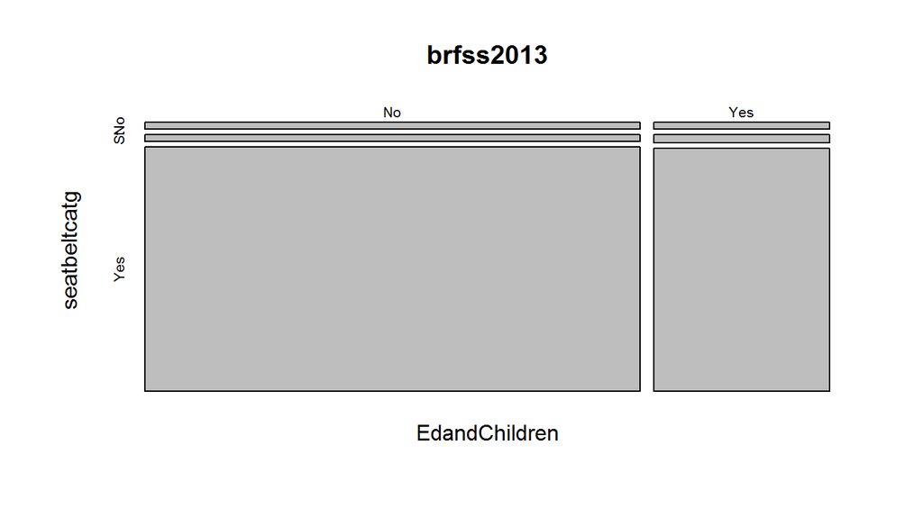

```r
mosaicplot(~ EdandChildren + seatbeltcatg, data = brfss2013)
```

The analysis of this mosaic plot shows that the two variables “EdandChildren” and “seatbeltcatg” are not associated since two columns are divided in relatively same vertical locations. That is, the verticle locations of 6 boxes are relatively same. The only difference is the horizontal lengths of the boxes which represent the number of observations of whether a household has children or not.

Further research is needed due to possible confounding variables such as seatbelt law enforcement. This might be an important factor to consider since if law enforcement is strong, whether or not one has children in his/her household might not matter. Seatbelt laws in the US are left to the states. Depending on which enforcement (either primary or secondary enforcement) each state’s seatbelt law applies, the degree of punishment for not wearing seatbelt differs. Thus, it would be important to consider where each observation is from. The large sample indicates that the samples examined in this study is generalizable, but since, mentioned before, this is an observational study, the result cannot imply any causal relationship between the two variables.

**Research quesion 3:**

As we are interested in exploring the relationship between fruit intake and freqency of feeling depressed in one month period, and whether consuming more fruits affects people to feel less depressed or sad. In order to explore this, it is important to first be familized with the two variables we are interested in (frutda1_ and qlmentl2). The variable ‘frutda1_’ represents fruit intake in times per day, and ‘qlmentl2’ notes how many days one felt sad, blue, or depressed during the past 30 days.

```r
brfss2013 %>%
select(frutda1_, qlmentl2) %>%
str()
```

```
## 'data.frame':    491775 obs. of  2 variables:
##  $ frutda1_: int  400 3 43 20 7 86 83 67 100 29 ...
##  $ qlmentl2: int  30 2 2 6 NA NA NA NA NA NA ...
```

With the structure function, we can see that both variables are numerical variables. Therefore, summary function is necessary to grasp the overall numerical summaries for both variables. First, I ran the summary statistics for the variable frutda1_

```r
with(brfss2013, summary(frutda1_))
```

```
##    Min. 1st Qu.  Median    Mean 3rd Qu.    Max.    NA's
##     0.0    33.0   100.0   101.7   100.0  9900.0   33800
```

I realized through above table that the variable had 2 decimal places, which means that I need the whole variable to be divded by 100 to get the fruit intake per day data. Therefore, I made a new variable ‘fruit_day’ which is the variable ‘frutda1_’ divded by 100.

```r
brfss2013 <- brfss2013 %>%
mutate(fruit_day = frutda1_ / 100)
```

Then I ran the summary statistics again for the variable ‘fruit_day’. Now, the data is reasonable, as the minimum is 0, 1st quartile is 0.33, median and third quartile are 1, mean is 1.02, and the maximum is 99, which is an outlier. Mean is slightly bigger than median by 0.02. Thus, by just looking at the summary statistics, it is relatively symmetric distribution.

```r
with(brfss2013, summary(fruit_day))
```

```
##    Min. 1st Qu.  Median    Mean 3rd Qu.    Max.    NA's
##    0.00    0.33    1.00    1.02    1.00   99.00   33800
```

However, in order to see how outliers are distributed for the variable ‘fruit_day’, I made a histogram with the variable.

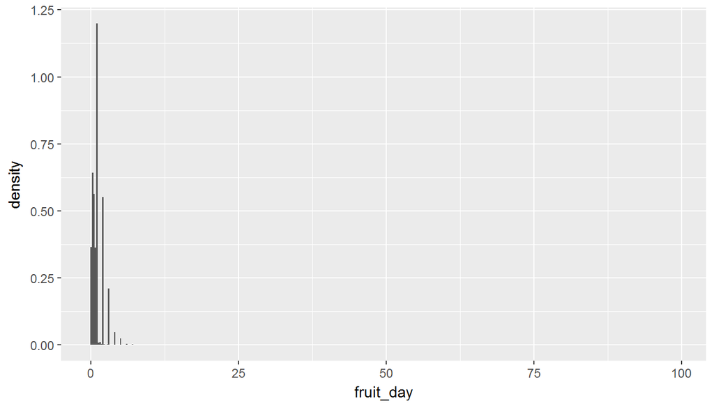

```r
brfss2013 %>%
filter(!is.na(fruit_day)) %>%
ggplot(aes(x = fruit_day)) + geom_histogram(binwidth = 0.25, aes(y = ..density..))
```

This shows that the variable is extremely right skewed, pulled out by the extreme outliers.

I also ran the summary statistics for ‘qlmentl2’, indicating how many days one felt sad, depressed, or blue during the past 30 days.

```r
with(brfss2013, summary(qlmentl2))
```

```
##    Min. 1st Qu.  Median    Mean 3rd Qu.    Max.    NA's
##     0.0     0.0     0.0     4.6     4.0    30.0  491284
```

The summary statistics show the appropriate range of data (0 to 30), as 30 is the maximum number of days one can answer. Median 0 is smaller than median 4.6. Thus, the variable qlmentl2 has a right-skewed distribution.

I also checked the distribution for the variable ‘qlment12’ below with histogram.

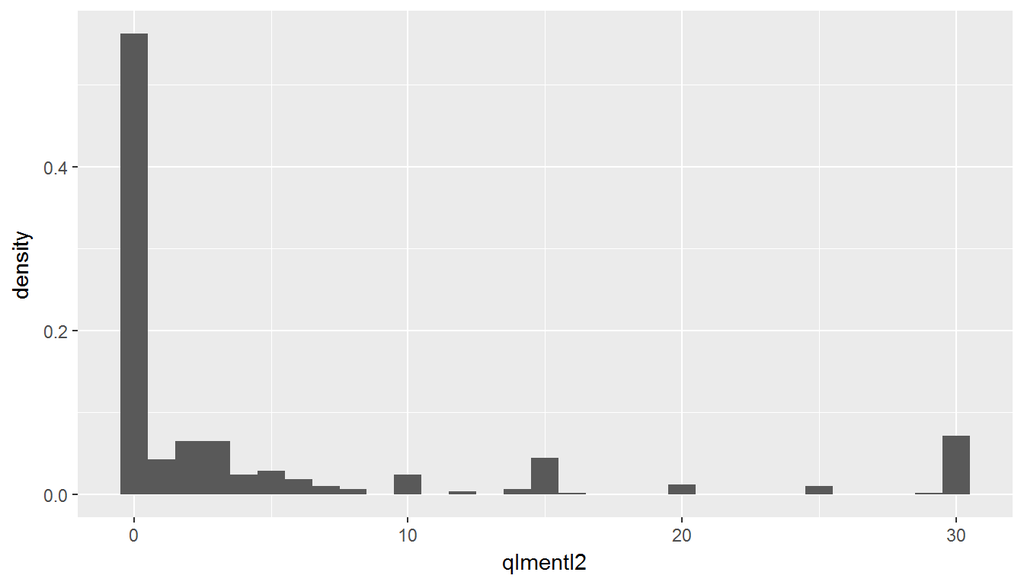

```r
brfss2013 %>%
filter(!is.na(qlmentl2)) %>%
ggplot(aes(x = qlmentl2)) + geom_histogram(binwidth = 1, aes(y = ..density..))
```

After observing distributions of each variable, I made a scatterplot, now to examine the number of fruit consumption of a person per day as an explanatory variable for the number of feeling sad, depressed, or blue for the past 30 days.

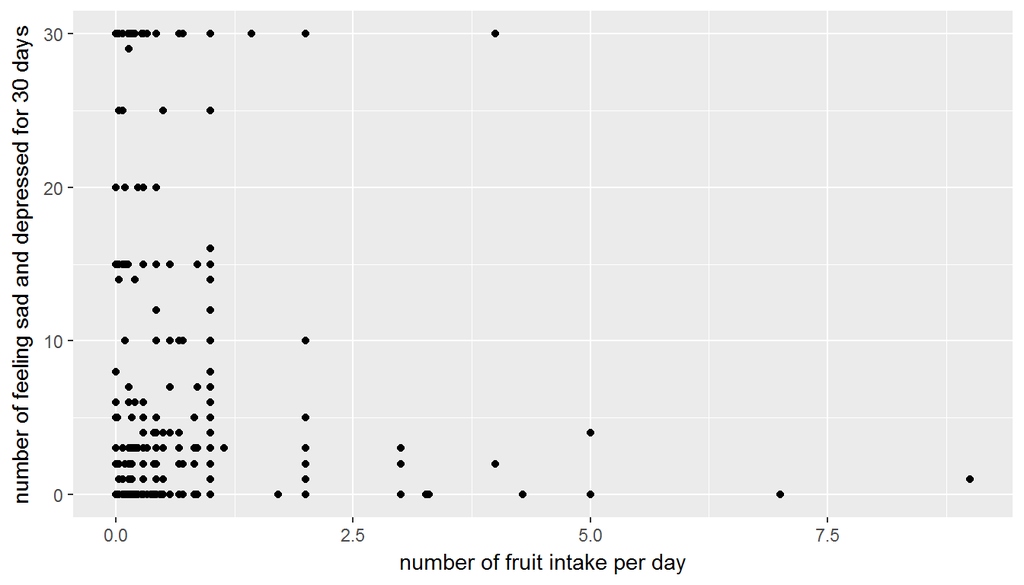

```r
brfss2013 %>%
filter(!is.na(fruit_day), !is.na(qlmentl2)) %>%
ggplot(aes(x = fruit_day, y = qlmentl2)) + geom_point() + xlab('number of fruit intake per day') + ylab('number of feeling sad and depressed for 30 days')
```

```r
with(brfss2013, cor(!is.na(fruit_day), !is.na(qlmentl2)))
```

```
## [1] 0.006297933
```